# Case Study: SEM - from Theory to Practice

Linking the Agricultural Landscape of the Midwest to Stream Health with Structural Equation Modeling [(Schmidt et al., 2019)](https://doi.org/10.1021/acs.est.8b04381)

Fabienne Wiederkehr

11/11/2020

## Introduction[^1]

The expanding human population as well as their actions on the landscape (e.g. developments in infrastructure, agriculture, and industry) threaten the ecological integrity of stream ecosystems. Understanding how these landscape modifications affect the stream habitat, water quality, and ultimately stream biology, is a primary goal of stream ecology and crucial for the development of effective management strategies that maintain our freshwater resources. Various studies have identified the physical and chemical alterations that likely influence biological communities, and how they relate to land-use and in-stream stressors. However, these studies did not test conceptual models of how physico-chemical and natural-landscape factors together with different types of land use interactively influence the integrity of biological communities. This is why Schmidt et al. (2019): «investigated hypothesised causal linkages between human development, physical and chemical stressors in streams, and stream ecological health using SEM».

For background, we here provide the abstract from their paper. Please refer to the study for more details.

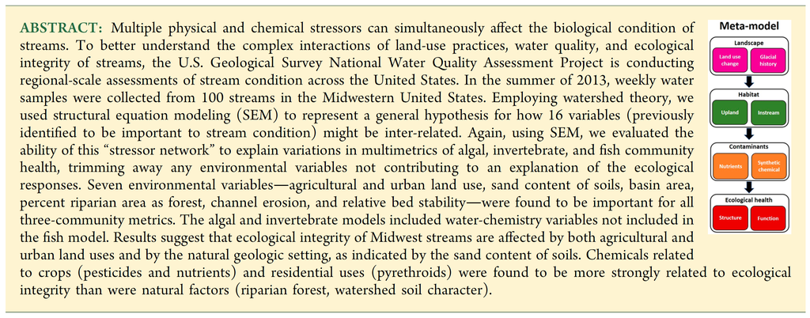

## Data Exploration

Schmidt et al. (2019) performed all modelling in R using the packages `psych`, `data.table`, `lavaan`, and `semPlot`, thus we, too, will (install and) load them. If you are not yet familiar with these packages, use the built-in help function (e.g. `?lavaan`) to find out more about them. The authors provide their data and metadata [here](https://www.sciencebase.gov/catalog/item/5b463148e4b060350a15a836)[^2], and the supplementary material [here](https://pubs.acs.org/doi/suppl/10.1021/acs.est.8b04381/suppl_file/es8b04381_si_001.pdf)[^3] (take a moment to look through the metadata and supplementary material, this study sets an excellent example in thorough documentation). We will download the data and get started in R:

```r
# Set working directory and load data
setwd("~/Git_Projects/Swiss_SEM/Case_Studies/Schmidt-et-al_2019")
dat <- read.csv("Schmidt-et-al_2019.csv", sep = ";")
```

First, we need to acquaint ourselves with the data (e.g. which variables are continuous, which categorical? do we have missing values? what is the spread of the data?). We need to inspect and transform the data to meet the assumptions of normality and heterogeneity of variance. Data scales impact the internal matrix manipulations. `lavaan` is fussy about data scales, since they impact the internal matrix manipulations. Although it will let us know if it has a problem with our data, it is good practice to inspect the data beforehands. The authors of this study list the specific transformations for predictor variables in Table S1, and those for the ecology variables in the main text. We transform the data accordingly:

```r
# Transform data
dat2 <- dat # duplicate data to avoid overwriting original data
dat2$BasinArea <- log10(dat$BasinArea) # example for how to log10-transform variable
```

After transformation, the data need to be centred and standardised “by subtracting the mean value for each variable from each observation and then dividing by the standard deviation of all observations for that variable”. Luckily, this is just what the function `scale()` does:

```r
# Centre and standardise data
dat3 <- data.table(scale(dat2[,-1])) # scale() function returns matrix, thus we apply data.table() function
dat3$TSTAID <- dat2$TSTAID # column TSTAID is non-numeric, thus we have to exclude it for scaling our data and append it afterwards
```

## Model Building

### Stressor Model

We are now ready to build our first model. `lavaan` uses a specific model syntax to describe structural equation models. Use the built-in help function `?model.syntax` and consult the section “Details” for more information. In their first model, the authors evaluated how land-use and natural-landscape features, riparian variables, in-stream conditions, nutrients, and chemicals were inter-related. They spent weeks going through an exhaustive yet realistic set of model scenarios to come up with a final stressor model. For the sake of time, we will sneak a peek at this final model. This is not cheating, exactly, since SEM is an explanatory framework for developing and evaluating complex hypotheses about systems—let us assume we did a very thorough literature search and came up with this hypothesised model:

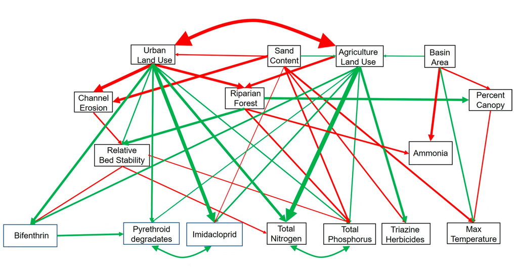

In `lavaan`, we need to take the following three steps:

Step 1: Specify model  
Step 2: Estimate/fit model  
Step 3: Extract results (both estimates and assessment of fit)

A model is specified by simply adding an equation for each response variable. A regression is specified by the “~” operator, whereby the dependent variable is on the left of a “~” operator and the independent variables, separated by “+” operators, are on the right. Covariances between variables are specified with the “~~” operator. If we go back to the paper, we find: «Structural equation models were fit in lavaan, using listwise deletion of missing values, with exogenous (causally independent variables) means, variances, and covariances treated as random. Model fit and parameter estimation was done using maximum likelihood estimation with robust errors.»

Try to find the correct arguments to fit the described model using `?sem`. Once we specified and fitted the model, we can extract the results:

```r
# Step 1: Specify model
mod.stressor <- '
  # Regressions
  UrbanTotal2011 ~ SandContent
  AgricultureTotal2011 ~ SandContent + BasinArea
  Bank ~ UrbanTotal2011 + SandContent
  r50_ForestTotal2011 ~ UrbanTotal2011 + AgricultureTotal2011
  PctCanopy ~ BasinArea + r50_ForestTotal2011
  RBS ~ UrbanTotal2011 + Bank + r50_ForestTotal2011
  NH3_MED_42DAY ~ BasinArea + r50_ForestTotal2011
  Bifenthrin ~ UrbanTotal2011 + AgricultureTotal2011 + RBS
  pyrethroid_deg_sum ~ UrbanTotal2011 + AgricultureTotal2011 + Bifenthrin
  imidacloprid ~ UrbanTotal2011 + SandContent + AgricultureTotal2011
  TN_MED_42DAY ~ UrbanTotal2011 + AgricultureTotal2011 + RBS
  TP_MED_42DAY ~ UrbanTotal2011 + SandContent + AgricultureTotal2011 + r50_ForestTotal2011 + RBS
  triazH ~ SandContent + AgricultureTotal2011
  Tmax42.C.OBSYN ~ SandContent + BasinArea + PctCanopy

  # Covariances
  UrbanTotal2011 ~~ AgricultureTotal2011
  pyrethroid_deg_sum ~~ imidacloprid
  TN_MED_42DAY ~~ TP_MED_42DAY
' # note that we renamed dat3$median.of.sumconcn_triazH to dat3$triazH for simplicity

# Step 2: Estimate model
fit.mod.stressor <- sem(mod.stressor, data = dat3, fixed.x = FALSE, estimator = "MLM") # sem() is used to fit model
# note: listwise deletion of missing values is the default setting; fixed.x = FALSE is used to treat exogenous means, variances, and covariances as random; estimator = "MLM" to use maximum likelihood estimation with robust errors to offset any bias introduced by non-normal distribution

# Step 3: Extract results
summary(fit.mod.stressor, standardized = TRUE, fit.measures = TRUE, rsquare = TRUE)
```

```
## lavaan 0.6-7 ended normally after 46 iterations
##
##   Estimator                                         ML
##   Optimization method                           NLMINB
##   Number of free parameters                         75
##
##                                                   Used       Total
##   Number of observations                            90          98
##
## Model Test User Model:
##                                               Standard      Robust
##   Test Statistic                                63.418      65.310
##   Degrees of freedom                                61          61
##   P-value (Chi-square)                           0.391       0.329
##   Scaling correction factor                                  0.971
##        Satorra-Bentler correction
##
## Model Test Baseline Model:
##
##   Test statistic                               655.455     539.503
##   Degrees of freedom                               119         119
##   P-value                                        0.000       0.000
##   Scaling correction factor                                  1.215
##
## User Model versus Baseline Model:
##
##   Comparative Fit Index (CFI)                    0.995       0.990
##   Tucker-Lewis Index (TLI)                       0.991       0.980
##
##   Robust Comparative Fit Index (CFI)                         0.992
##   Robust Tucker-Lewis Index (TLI)                            0.984
##
## Loglikelihood and Information Criteria:
##
##   Loglikelihood user model (H0)              -1741.417   -1741.417
##   Loglikelihood unrestricted model (H1)      -1709.708   -1709.708
##
##   Akaike (AIC)                                3632.834    3632.834
##   Bayesian (BIC)                              3820.319    3820.319
##   Sample-size adjusted Bayesian (BIC)         3583.614    3583.614
```

[output cut: 131 more lines]

```
##                    Estimate
##     UrbanTotal2011    0.042
##     AgrcltrTtl2011    0.074
##     Bank              0.558
##     r50_FrstTt2011    0.146
##     PctCanopy         0.354
##     RBS               0.333
##     NH3_MED_42DAY     0.055
##     Bifenthrin        0.154
##     pyrethrd_dg_sm    0.217
##     imidacloprid      0.372
##     TN_MED_42DAY      0.577
##     TP_MED_42DAY      0.373
##     triazH            0.251
##     Tmax42.C.OBSYN    0.248
```

Once the authors were happy with their model, they went over to a robust fit approach using Bollen-Stine bootstrap (*n* = 1000). Since the data set is relatively small (only 98 observations) compared to how complicated the model is, they were concerned that the MLM approach might find significant path coefficients not supported by the robust approach. Thus, they only included paths that were significant using the MLM and robust fits. Note that bootstrapping uses random sampling with replacement, thus our results will differ slightly from run to run. To prevent this, we can set the seed of R’s random number generator: `set.seed()`. We can run a Bollen-Stine bootstrap SEM in R by adding the term: `test = "bollen.stine", se = "boot", bootstrap = 1000`. This may take a while:

```r
# Ensure reproducibility of results
set.seed(123)

# Bollen-Stine bootstrap
fit.mod.stressor.bs <- sem(mod.stressor, data = dat3, test = "bollen.stine", se = "boot", bootstrap = 1000, fixed.x = FALSE)
head(standardizedSolution(fit.mod.stressor.bs)) # we use head() to only display the first few rows
```

```
##                    lhs op            rhs est.std    se      z pvalue ci.lower
## 1       UrbanTotal2011  ~    SandContent  -0.206 0.075 -2.749  0.006   -0.352
## 2 AgricultureTotal2011  ~    SandContent   0.182 0.085  2.130  0.033    0.015
## 3 AgricultureTotal2011  ~      BasinArea   0.190 0.069  2.743  0.006    0.054
## 4                 Bank  ~ UrbanTotal2011  -0.658 0.105 -6.269  0.000   -0.864
## 5                 Bank  ~    SandContent  -0.514 0.111 -4.632  0.000   -0.732
## 6  r50_ForestTotal2011  ~ UrbanTotal2011  -0.481 0.137 -3.521  0.000   -0.749
##   ci.upper
## 1   -0.059
## 2    0.349
## 3    0.326
## 4   -0.452
## 5   -0.297
## 6   -0.213
```

It is good practice to report the covariance matrix in the supplementary material:

```r
# Request covariance matrix
lavInspect(fit.mod.stressor.bs, what = "sampstat")
```

### Algal Model

Schmidt et al. (2019) applied the optimised stressor model to their ecological indicators. To start with, we will examine the effects of the various stressors on the integrity of algal communities. Due to the lack of a commonly-used multi-metric algal index, the authors: «developed a latent variable comprising three metrics that represent the tolerance/sensitivity of three diatom taxon groups to a wide range of disturbances». For more details on how Schmidt et al. (2019) derived BC2-4, the measures of the latent variable “Algal Community Health”, please refer to the methods section of the study. To specify the algal model, we take the optimised stressor model, add a latent-variable construct specifying “Algal Community Health”, and add a path from each stressor variable to “Algal Community Health”:

```r
# Step 1: Specify model
mod.algae <- '
  # Latent Construct
  Algae =~ BC_2.RelAbun + BC_3.RelAbun + BC_4.RelAbun

  # Regressions
  UrbanTotal2011 ~ SandContent
  AgricultureTotal2011 ~ SandContent + BasinArea
  Bank ~ UrbanTotal2011 + SandContent
  r50_ForestTotal2011 ~ UrbanTotal2011 + AgricultureTotal2011
  PctCanopy ~ BasinArea + r50_ForestTotal2011
  RBS ~ UrbanTotal2011 + Bank + r50_ForestTotal2011
  NH3_MED_42DAY ~ BasinArea + r50_ForestTotal2011
  Bifenthrin ~ UrbanTotal2011 + AgricultureTotal2011 + RBS
  pyrethroid_deg_sum ~ UrbanTotal2011 + AgricultureTotal2011 + Bifenthrin
  imidacloprid ~ UrbanTotal2011 + SandContent + AgricultureTotal2011
  TN_MED_42DAY ~ UrbanTotal2011 + AgricultureTotal2011 + RBS
  TP_MED_42DAY ~ UrbanTotal2011 + SandContent + AgricultureTotal2011 + r50_ForestTotal2011 + RBS
  median.of.sumconcn_triazH ~ SandContent + AgricultureTotal2011
  Tmax42.C.OBSYN ~ SandContent + BasinArea + PctCanopy
  Algae ~ UrbanTotal2011 + SandContent + AgricultureTotal2011 + BasinArea + Bank + r50_ForestTotal2011
          + PctCanopy + RBS + NH3_MED_42DAY + Bifenthrin + pyrethroid_deg_sum + imidacloprid + TN_MED_42DAY
          + TP_MED_42DAY + median.of.sumconcn_triazH + Tmax42.C.OBSYN

  # Covariances
  UrbanTotal2011 ~~ AgricultureTotal2011
  pyrethroid_deg_sum ~~ imidacloprid
  TN_MED_42DAY ~~ TP_MED_42DAY
'

# Step 2: Estimate model
fit.mod.algae <- sem(mod.algae, data = dat3, missing = "listwise", fixed.x = FALSE, estimator = "MLM")

# Step 3: Extract results
standardizedSolution(fit.mod.algae)
```

Unsurprisingly, this initial model performs really badly. Some stressor variables might affect “Algal Community Health” indirectly only, while others might have no effect at all. The authors write: «Models were iteratively evaluated trimming path coefficients that were not significant». Iteratively means we trim the path with the highest *p*-value first, fit the resulting model, extract its results etc (note: since Schmidt et al. (2019) report standardised path coefficients, we want the *p*-values from the function `standardizedSolution()`):

```r
# Trim Algae ~ SandContent
# Step 1: Specify model
mod.algae.2 <- '
  # Latent Construct
  Algae =~ BC_2.RelAbun + BC_3.RelAbun + BC_4.RelAbun

  # Regressions
  UrbanTotal2011 ~ SandContent
  AgricultureTotal2011 ~ SandContent + BasinArea
  Bank ~ UrbanTotal2011 + SandContent
  r50_ForestTotal2011 ~ UrbanTotal2011 + AgricultureTotal2011
  PctCanopy ~ BasinArea + r50_ForestTotal2011
  RBS ~ UrbanTotal2011 + Bank + r50_ForestTotal2011
  NH3_MED_42DAY ~ BasinArea + r50_ForestTotal2011
  Bifenthrin ~ UrbanTotal2011 + AgricultureTotal2011 + RBS
  pyrethroid_deg_sum ~ UrbanTotal2011 + AgricultureTotal2011 + Bifenthrin
  imidacloprid ~ UrbanTotal2011 + SandContent + AgricultureTotal2011
  TN_MED_42DAY ~ UrbanTotal2011 + AgricultureTotal2011 + RBS
  TP_MED_42DAY ~ UrbanTotal2011 + SandContent + AgricultureTotal2011 + r50_ForestTotal2011 + RBS
  median.of.sumconcn_triazH ~ SandContent + AgricultureTotal2011
  Tmax42.C.OBSYN ~ SandContent + BasinArea + PctCanopy
  Algae ~ UrbanTotal2011 + AgricultureTotal2011 + BasinArea + Bank + r50_ForestTotal2011 + PctCanopy + RBS + NH3_MED_42DAY + Bifenthrin + pyrethroid_deg_sum
          + imidacloprid + TN_MED_42DAY + TP_MED_42DAY + median.of.sumconcn_triazH + Tmax42.C.OBSYN

  # Covariances
  UrbanTotal2011 ~~ AgricultureTotal2011
  pyrethroid_deg_sum ~~ imidacloprid
  TN_MED_42DAY ~~ TP_MED_42DAY
'

# Step 2: Estimate model
fit.mod.algae.2 <- sem(mod.algae.2, data = dat3, missing = "listwise", fixed.x = FALSE, estimator = "MLM")

# Step 3: Extract results
standardizedSolution(fit.mod.algae.2)
```

Once there are no non-significant paths left (hint: you can see how many models I compared by the numbering), we investigate: are we missing any important links? Modification indices measure the distance between fitted and implied covariance matrices and suggest additional paths that could improve model fit. Here, we are interested in modification indices > 4:

```r
mi.algae.13 <- modindices(fit.mod.algae.13, standardized = FALSE); print(mi.algae.13[mi.algae.13$mi > 4.0,])
```

```
##                           lhs op                       rhs     mi    epc
## 117                 PctCanopy ~~              TN_MED_42DAY  4.387 -0.106
## 125              TN_MED_42DAY ~~ median.of.sumconcn_triazH 12.768 -0.211
## 127              TP_MED_42DAY ~~ median.of.sumconcn_triazH 12.737  0.269
## 136            UrbanTotal2011  ~              TP_MED_42DAY  4.572 -0.768
## 138            UrbanTotal2011  ~            Tmax42.C.OBSYN  5.216 -0.193
## 147      AgricultureTotal2011  ~              TP_MED_42DAY  5.440 -0.595
## 194              TN_MED_42DAY  ~ median.of.sumconcn_triazH 13.660 -0.249
## 202              TP_MED_42DAY  ~ median.of.sumconcn_triazH 12.737  0.315
## 211 median.of.sumconcn_triazH  ~              TN_MED_42DAY  8.021 -0.343
## 253                 BasinArea  ~                     Algae  4.380 -0.511
```

Most suggestions do not make sense biologically. However, we think a covariance relationship between “Total Phosphorus” and “Triazine Herbizides” is indeed likely. We add this path and compare the two models using AIC<sub>C</sub>. For this, we (install and) load the package `AICcmodavg` and use the function `aictab()`:

```r
# Compare algal models
aictab(list(fit.mod.algae.13, fit.mod.algae.14), c("Model 13", "Model 14"))
```

```
##
## Model selection based on AICc:
##
##           K    AICc Delta_AICc AICcWt Cum.Wt       LL
## Model 14 53 3684.52       0.00   0.92   0.92 -1715.87
## Model 13 52 3689.45       4.93   0.08   1.00 -1723.82
```

Adding this link is indeed supported, so we choose model 14. Let us inspect whether any path coefficients are non-significant in our newest algal model. This is not the case, and so we estimate the path coefficients using Bollen-Stine bootstrap (*n* = 1000):

```r
set.seed(301)
fit.mod.algae.14.bs <- sem(fit.mod.algae.14, data = dat3, test = "bollen.stine", se = "boot", bootstrap = 1000, fixed.x = FALSE)
standardizedSolution(fit.mod.algae.14.bs)
```

Again, we inspect the `standardizedSolution` output for any non-significant standardised path coefficients (*p*-value > 0.10), trim the model iteratively, and compare the models using a selection of fit measures:

```r
# Compare algal models
fitMeasures(fit.mod.algae.15, c("chisq.scaled", "df.scaled", "pvalue.scaled", "cfi.scaled", "ifi"))
```

```
##  chisq.scaled     df.scaled pvalue.scaled    cfi.scaled           ifi
##        78.177        68.000         0.187         0.976         0.976
```

```r
fitMeasures(fit.mod.algae.16, c("chisq.scaled", "df.scaled", "pvalue.scaled", "cfi.scaled", "ifi"))
```

```
##  chisq.scaled     df.scaled pvalue.scaled    cfi.scaled           ifi
##        61.661        59.000         0.381         0.992         0.991
```

Model 16 is a better fit. Again, we estimate the path coefficients using Bollen-Stine bootstrap (*n* = 1000):

```r
# Bootstrap
set.seed(301)
fit.mod.algae.16.bs <- sem(fit.mod.algae.16, data = dat3, test = "bollen.stine", se = "boot", bootstrap = 1000, fixed.x = FALSE)
head(standardizedSolution(fit.mod.algae.16.bs))
```

```
##                    lhs op          rhs est.std    se      z pvalue ci.lower
## 1                Algae =~ BC_2.RelAbun   0.691 0.083  8.291  0.000    0.527
## 2                Algae =~ BC_3.RelAbun   0.730 0.100  7.273  0.000    0.533
## 3                Algae =~ BC_4.RelAbun  -0.485 0.127 -3.801  0.000   -0.734
## 4       UrbanTotal2011  ~  SandContent  -0.221 0.066 -3.358  0.001   -0.350
## 5 AgricultureTotal2011  ~  SandContent   0.203 0.078  2.600  0.009    0.050
## 6 AgricultureTotal2011  ~    BasinArea   0.188 0.066  2.833  0.005    0.058
##   ci.upper
## 1    0.854
## 2    0.927
## 3   -0.235
## 4   -0.092
## 5    0.357
## 6    0.319
```

This time, the Bollen-Stine bootstrap does not find any further non-significant paths. This means we found our final algal model! We discuss selected path coefficients in the main text, report the standardised path coefficients (along with their SE, z-score *p*-value, and *R*<sup>2</sup>), fit statistics, and covariance matrix in the supplementary material, and ideally illustrate all paths in a figure.

### Fish Model

[^1]: Schmidt, T.S., Van Metre, P.C., Carlisle, D.M. (2019). Linking the Agricultural Landscape of the Midwest to Stream Health with Structural Equation Modeling. *Environmental Science Technology*, *53*, 452-462. https://doi.org/10.1021/acs.est.8b04381
[^2]: https://www.sciencebase.gov/catalog/item/5b463148e4b060350a15a836
[^3]: https://pubs.acs.org/doi/suppl/10.1021/acs.est.8b04381/suppl_file/es8b04381_si_001.pdf